# Simple models for beech forests

For Stoat control in Beech forest paper

Anthony Davidson

2019-05-16

# Overview

New Zealand beech forests exhibit boom-bust dynamics (Figure 1). Where, beech trees mast in spatial synchronised but annually variable years dependant (Wardle 1991). Mice populations have invaded these systems and studies have shown that populations response numerically to changes in resources (beech seed) and mice have been modelled under a range of both functional and numerical responses (King 1983).

This short report investigates the possible bias in the estimation of available seed to the raw data commonly used for estimation of food availability (Ruscoe et al. 2005). This is important because the following bias are known and need to be accounted for before analysising data.

1. Seeds without the kernal have no energy value and need to be removed.
2. Different beech species produce different sized seeds and this has an effect on the “available seed”.
3. As our models build in complexity we will include a variety of food resources and therefore need to model these relationships in the future

# Introduction and Methods

*Generally look at thesis drafts here.*

This RMarkdown file is intend to be extended on for different species of trees, fruit and seed. These files are the supporting documetation to the data-wrangling code in the Beech forest manuscript here.

Bbut there is also many other supporting resources and less formal tutorials on my [website](https://www.ssnhub.com) and the feed below:

# Invasive species notes

[output not shown]

## Meta-data

### Contents

- [Current draft](https://www.dropbox.com/home/phd-drafts-anthony/beech-forest-dynamics/drafts/Davidson_2019_BeechForest.html)
- [Style sheet](https://www.dropbox.com/home/phd-drafts-anthony/beech-forest-dynamics/Styles_manual_sheet.md/)
- [Introduction](https://www.dropbox.com/sh/5h4mp67p7u6t1lj/AAAQVKS4qnvu2oQLu53JQUofa?dl=0)
- [Bayesian methods](https://www.dropbox.com/home/phd-drafts-anthony/beech-forest-dynamics/A1_full_bayesian_model.pdf)
- [Figures](https://www.dropbox.com/home/phd-drafts-anthony/beech-forest-dynamics/figs)
- [Functional response](https://www.dropbox.com/home/phd-drafts-anthony/beech-forest-dynamics/Davidson_2019_BeechForest_Appendix.pdf)
- References: *coming online soon*

All other data and resources to render project from raw data (copied from my private GIT repository) can be found on [dropbox](https://www.dropbox.com/home/phd-drafts-anthony) but will be available here when I have incorporated the co-authors feedback

[output not shown]

## Importing data

The orginal data was in excel format and manually covered to csv as below. This has had the non-viable material removed and only whole kernals of seed for three species of beech tree were reported.

```r
# raw seed file generated from input file
# create seed data file
#laptop
#seed <- read_csv("C://GIT/beech-paper-private/manuscript/data/seed_data_jan2017.csv")

#desktop
seed <- read_csv("C://Code/beech-paper-private/manuscript/data/seed_data_jan2017.csv")
```

## Data wrangling

This is just me looking at a few of the seed dynamics of the raw dataset. (After the removal of non-nutrious material)

### Seed Measurement

The data is very clean with all the information but to make life simplier for the analysis and bindng to output data to be correct.

#### Method - `metre sq (m2)`

1. `Bucket radius = 0.125m`
2. `Bucket area = 0.049087385m2`
3. `4 buckets per grid = total catch area = 0.19635 m2`
4. `So seeds /m2 =# Seeds counted/0.1963`

Therefore, if $800$ seeds were counted on a grid on a particular trip, this will equate to $4000 m^2$.

### Variable structure

I have defined the following parameters that help to keep the type of variable the same throughout the joining of the raw data and the model outputs.

```r
#month levels to get it right
month_levels <- c("Jan", "Feb", "Mar", "Apr", "May", "Jun","Jul", "Aug", "Sep", "Oct", "Nov", "Dec")

# Grid labels
labels <- c("egl M1" = "Grid one",
            "egl M2" = "Grid two",
            "egl MR1" = "Grid three",
            "egl MR2" = "Grid four",
            "hol M1" = "Grid five",
            "hol M2" = "Grid six",
            "hol MR1" = "Grid seven",
            "hol MR2" = "Grid eight")

# Valley labels
labels2 <- c(egl = "Eglinton valley", hol = "Hollyford valley")
```

In this the structure of the variables for the seed dataset have to be joint and visualised we need to insure that there are the same number of replicates in this dataset as the output dataset (from the JAGS model).

### Tidyverse

To aviod issues with factors and data management I have used the following pre-print publications authored by the creators of `dplyr` and `ggplot2`. Tidyverse is a group of packages that together make use a `tidy` approach effective.

Here is some more information about the tidyverse approach

### Find extra trips and grids

### Remove additional data

## Final seed dataset

```
Observations: 144
Variables: 13
Groups: grid, year [44]
$ valley       <chr> "egl", "egl", "egl", "egl", "egl", "egl", "egl", ...
$ red          <dbl> 81, 5, 1, 0, 222, 48, 1, 0, 0, 0, 0, 0, 0, 0, 2, ...
$ silver       <dbl> 31, 1, 0, 0, 31, 26, 2, 0, 0, 0, 0, 1, 0, 0, 1, 0...
$ seedm2       <dbl> 590.781767, 30.557678, 10.185893, 20.371785, 1303...
$ grid.id      <chr> "M1", "M1", "M1", "M1", "M1", "M1", "M1", "M1", "...
$ grid         <chr> "egl M1", "egl M1", "egl M1", "egl M1", "egl M1",...
$ trip.no      <dbl> 1, 2, 3, 4, 5, 6, 7, 8, 9, 10, 11, 12, 13, 14, 15...
$ year         <dbl> 1999, 1999, 1999, 2000, 2000, 2000, 2000, 2001, 2...
$ month        <fct> May, Aug, Nov, Feb, May, Aug, Nov, Feb, May, Aug,...
$ total        <dbl> 116, 6, 2, 4, 256, 74, 3, 0, 0, 0, 0, 1, 0, 0, 4,...
$ cum.seed     <dbl> 590.781767, 621.339445, 631.525337, 20.371785, 13...
$ trip         <dbl> 1, 2, 3, 4, 5, 6, 7, 8, 9, 10, 11, 12, 13, 14, 15...
$ log.cum.seed <dbl> 2.7721616, 2.7940273, 2.8010779, 1.3298408, 3.122...
```

# Descriptive plots

## Temporal variation in seed

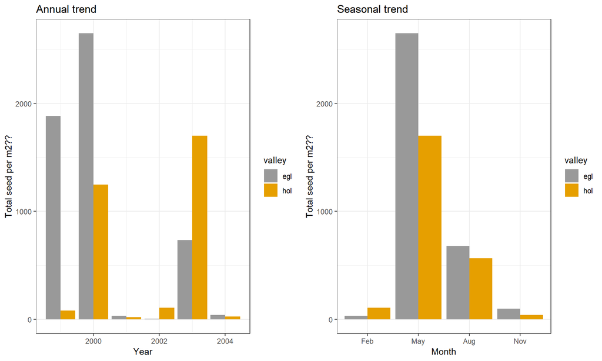

### Seasonal factorisation

In the data the seasonal parameter is month where:

| Month | Season | Factor level |
| --- | --- | --- |
| February | Summer | 1 |
| May | Autumn | 2 |
| August | Winter | 3 |
| November | Spring | 4 |

# Mouse dataset

The mouse dataset is generated from the full CR model found here

## Import data

The seed data above needs to be joined to the mouse dataset below. I will step through this process to insure that there are no errors in the merging of the two datasets.

## Output data

The output data of the model is in JAGS format. This means that it needs to be converted into a `dataframe` format. There are many different ways to do this. I have choosen the following tidy approach.

### JAGS output

*JAGSui output* (Kellner 2018).

#### Naming variable

#### Extract only N

## Restructuring dataset

### Group levels

THis has been hard to do with as little manual mistakes in factor levels as possible. The levelling structure should be the same throughout this document as descripted in beech data above. But in short:

```r
#month levels to get it right
month_levels <- c("Jan", "Feb", "Mar", "Apr", "May", "Jun","Jul", "Aug", "Sep", "Oct", "Nov", "Dec")

# full dates
true.date <- as.Date(c("1999-05-01","1999-08-01","1999-11-01","2000-02-01","2000-05-01","2000-08-01","2000-11-01","2001-02-01","2001-05-01","2001-08-01", "2001-11-01","2002-05-01","2002-11-01","2003-02-01","2003-05-01","2003-08-01","2003-11-01","2004-02-01","2004-05-01","2004-08-01"))

# Grid labels
labels <- c("egl M1" = "Grid one",
            "egl M2" = "Grid two",
            "egl MR1" = "Grid three",
            "egl MR2" = "Grid four",
            "hol M1" = "Grid five",
            "hol M2" = "Grid six",
            "hol MR1" = "Grid seven",
            "hol MR2" = "Grid eight")

# Valley labels
labels2 <- c(egl = "Eglinton valley", hol = "Hollyford valley")

# COntrol labels
# Stoats yes/no


# Conditions labals
# Rats yes/no

# Full treatment
# 6 levels
treat.six.levels <- c("hol no control rats.removed",
                                     "hol control rats.present",
                                     "hol control rats.removed",
                                     "egl control rats.present",
                                     "egl control rats.removed" ,
                                     "hol no control rats.present")
```

### Adding grouping variables

### Reduced seed joining dataset

Check the structure of this to make sure that the variables being joined are being correctly merged.

```
Observations: 144
Variables: 6
Groups: grid, year [44]
$ grid     <chr> "egl M1", "egl M1", "egl M1", "egl M1", "egl M1", "eg...
$ trip     <dbl> 1, 2, 3, 4, 5, 6, 7, 8, 9, 10, 11, 12, 13, 14, 15, 16...
$ year     <dbl> 1999, 1999, 1999, 2000, 2000, 2000, 2000, 2001, 2001,...
$ month    <fct> May, Aug, Nov, Feb, May, Aug, Nov, Feb, May, Aug, Nov...
$ cum.seed <dbl> 590.781767, 621.339445, 631.525337, 20.371785, 1324.1...
$ valley   <chr> "egl", "egl", "egl", "egl", "egl", "egl", "egl", "egl...
```

```
 [1] "Jan" "Feb" "Mar" "Apr" "May" "Jun" "Jul" "Aug" "Sep" "Oct" "Nov"
[12] "Dec"
```

[output not shown]

```
  [1] "1"   "2"   "3"   "4"   "5"   "6"   "7"   "8"   "9"   "10"  "11"
 [12] "12"  "13"  "14"  "15"  "16"  "17"  "18"  "19"  "20"  "21"  "22"
 [23] "23"  "24"  "25"  "26"  "27"  "28"  "29"  "30"  "31"  "32"  "33"
 [34] "34"  "35"  "36"  "37"  "38"  "39"  "40"  "41"  "42"  "43"  "44"
 [45] "45"  "46"  "47"  "48"  "49"  "50"  "51"  "52"  "53"  "54"  "55"
 [56] "56"  "57"  "58"  "59"  "60"  "61"  "62"  "63"  "64"  "65"  "66"
 [67] "67"  "68"  "69"  "70"  "71"  "72"  "73"  "74"  "75"  "76"  "77"
 [78] "78"  "79"  "80"  "81"  "82"  "83"  "84"  "85"  "86"  "87"  "88"
 [89] "89"  "90"  "91"  "92"  "93"  "94"  "95"  "96"  "97"  "98"  "99"
[100] "100" "101" "102" "103" "104" "105" "106" "107" "108" "109" "110"
[111] "111" "112" "113" "114" "115" "116" "117" "118" "119" "120" "121"
[122] "122" "123" "124" "125" "126" "127" "128" "129" "130" "131" "132"
[133] "133" "134" "135" "136" "137" "138" "139" "140" "141" "142" "143"
[144] "144"
```

[output not shown]

[output cut: 232 more lines]

```
137

138

139

140

141

142

143

144
```

### Joining seed and mice

### Stoat control

**control variable**

### Added rat Conditions

```
Observations: 144
Variables: 20
$ N              <dbl> 85.185920, 141.346453, 125.542907, 23.769273, 8...
$ se.N           <dbl> 17.258336, 24.813696, 15.717429, 1.661358, 18.5...
$ lcl.N          <dbl> 53, 103, 100, 22, 57, 88, 93, 25, 13, 0, 1, 1, ...
$ ucl.N          <dbl> 114, 200, 162, 28, 125, 179, 164, 43, 26, 5, 5,...
$ var            <chr> "N[1,1]", "N[2,1]", "N[3,1]", "N[4,1]", "N[5,1]...
$ grid           <chr> "egl M1", "egl M1", "egl M1", "egl M1", "egl M1...
$ trip           <dbl> 1, 2, 3, 4, 5, 6, 7, 8, 9, 10, 11, 12, 13, 14, ...
$ grid.n         <dbl> 1, 1, 1, 1, 1, 1, 1, 1, 1, 1, 1, 1, 1, 1, 1, 1,...
$ trip.no        <dbl> 1, 2, 3, 4, 5, 6, 7, 8, 9, 10, 11, 12, 13, 14, ...
$ valley         <chr> "egl", "egl", "egl", "egl", "egl", "egl", "egl"...
$ control        <chr> "control", "control", "control", "control", "co...
$ Valley         <fct> egl, egl, egl, egl, egl, egl, egl, egl, egl, eg...
$ year           <dbl> 1999, 1999, 1999, 2000, 2000, 2000, 2000, 2001,...
$ month          <fct> May, Aug, Nov, Feb, May, Aug, Nov, Feb, May, Au...
$ cum.seed       <dbl> 590.781767, 621.339445, 631.525337, 20.371785, ...
$ seed.account.N <dbl> 6.9352044, 4.3958616, 5.0303546, 0.8570639, 14....
$ log.seed       <dbl> 2.7714271, 2.7933289, 2.8003908, 1.3090291, 3.1...
$ valley.rep     <chr> "egl", "egl", "egl", "egl", "egl", "egl", "egl"...
$ grid.rats      <fct> M1, M1, M1, M1, M1, M1, M1, M1, M1, M1, M1, M1,...
$ Conditions     <chr> "rats.removed", "rats.removed", "rats.removed",...
```

### More grouping options

### Re-leveling

Just a final check that everything has worked.

# Saved datasets

I will save the final dataset for the analysis of the Beech foret data for the publication as so: The final plots. All extended plots are in the `Rcode/figures/`. These plots focus on simplifying the general trends and confirming any previous predictions.

## Study design

CR-design is complex and when treatments and conditions change through time it can be very hard to explain the data collection methods well. We have therefore constructed a diagram of the study design process.

### Data

```
[1] "Conditions" "valley"     "control"    "reps"       "limit"
[6] "true.date"  "treat.six"
```

```
Conditions

valley

control

reps

limit

true.date

treat.six
```

| N | se.N | lcl.N | ucl.N | var | grid | trip | grid.n | trip.no | valley | control | Valley | year | month | cum.seed | seed.account.N | log.seed | valley.rep | grid.rats | Conditions | grouping.1 | grouping.2 | grouping.3 | grouping.4 | true.date | treat.six | Rats | Control | Date | Treatments | … |
| --- | --- | --- | --- | --- | --- | --- | --- | --- | --- | --- | --- | --- | --- | --- | --- | --- | --- | --- | --- | --- | --- | --- | --- | --- | --- | --- | --- | --- | --- | --- |
| 85.1859200 | 17.2583357 | 53 | 114 | N[1,1] | 1 | 1 | 1 | 1 | egl | control | Eglinton | 1999 | May | 590.781767 | 6.9352044 | 2.7714271 | egl | M1 | rats.removed | treat.highN | treat.highN | treat.highN | treat.highN | 1999-05-01 | egl control rats.removed | Reduced | Yes | 1999-05-01 | egl control rats.removed | … |
| 141.3464533 | 24.8136961 | 103 | 200 | N[2,1] | 1 | 2 | 1 | 2 | egl | control | Eglinton | 1999 | Aug | 621.339445 | 4.3958616 | 2.7933289 | egl | M1 | rats.removed | treat.highN | treat.highN | treat.highN | treat.highN | 1999-08-01 | egl control rats.removed | Reduced | Yes | 1999-08-01 | egl control rats.removed | … |
| 125.5429067 | 15.7174287 | 100 | 162 | N[3,1] | 1 | 3 | 1 | 3 | egl | control | Eglinton | 1999 | Nov | 631.525337 | 5.0303546 | 2.8003908 | egl | M1 | rats.removed | treat.highN | treat.highN | treat.highN | treat.highN | 1999-11-01 | egl control rats.removed | Reduced | Yes | 1999-11-01 | egl control rats.removed | … |
| 23.7692733 | 1.6613580 | 22 | 28 | N[4,1] | 1 | 4 | 1 | 4 | egl | control | Eglinton | 2000 | Feb | 20.371785 | 0.8570639 | 1.3090291 | egl | M1 | rats.removed | treat.lowN | treat.highN | treat.highN | treat.highN | 2000-02-01 | egl control rats.removed | Reduced | Yes | 2000-02-01 | egl control rats.removed | … |
| 89.5302533 | 18.5405013 | 57 | 125 | N[5,1] | 1 | 5 | 1 | 5 | egl | control | Eglinton | 2000 | May | 1324.166030 | 14.7901517 | 3.1219424 | egl | M1 | rats.removed | treat.highN | treat.highN | treat.highN | treat.highN | 2000-05-01 | egl control rats.removed | Reduced | Yes | 2000-05-01 | egl control rats.removed | … |
| 132.5741133 | 24.5620601 | 88 | 179 | N[6,1] | 1 | 6 | 1 | 6 | egl | control | Eglinton | 2000 | Aug | 1701.044054 | 12.8308914 | 3.2307156 | egl | M1 | rats.removed | treat.highN | treat.highN | treat.highN | treat.highN | 2000-08-01 | egl control rats.removed | Reduced | Yes | 2000-08-01 | egl control rats.removed | … |
| 122.0759400 | 18.1190611 | 93 | 164 | N[7,1] | 1 | 7 | 1 | 7 | egl | control | Eglinton | 2000 | Nov | 1716.322893 | 14.0594690 | 3.2345990 | egl | M1 | rats.removed | treat.highN | treat.highN | treat.highN | treat.highN | 2000-11-01 | egl control rats.removed | Reduced | Yes | 2000-11-01 | egl control rats.removed | … |
| 31.7279867 | 4.5500564 | 25 | 43 | N[8,1] | 1 | 8 | 1 | 8 | egl | control | Eglinton | 2001 | Feb | 0.000000 | 0.0000000 | 0.0000000 | egl | M1 | rats.removed | treat.lowN | treat.highN | treat.lowN | treat.lowN | 2001-02-01 | egl control rats.removed | Reduced | Yes | 2001-02-01 | egl control rats.removed | … |
| 17.7766000 | 3.4972180 | 13 | 26 | N[9,1] | 1 | 9 | 1 | 9 | egl | control | Eglinton | 2001 | May | 0.000000 | 0.0000000 | 0.0000000 | egl | M1 | rats.removed | treat.lowN | treat.highN | treat.lowN | treat.lowN | 2001-05-01 | egl control rats.removed | Reduced | Yes | 2001-05-01 | egl control rats.removed | … |
| 1.7254933 | 1.4848549 | 0 | 5 | N[10,1] | 1 | 10 | 1 | 10 | egl | control | Eglinton | 2001 | Aug | 0.000000 | 0.0000000 | 0.0000000 | egl | M1 | rats.removed | treat.lowN | treat.lowN | treat.lowN | treat.lowN | 2001-08-01 | egl control rats.removed | Reduced | Yes | 2001-08-01 | egl control rats.removed | … |

[output cut: 134 more lines]

### Plot

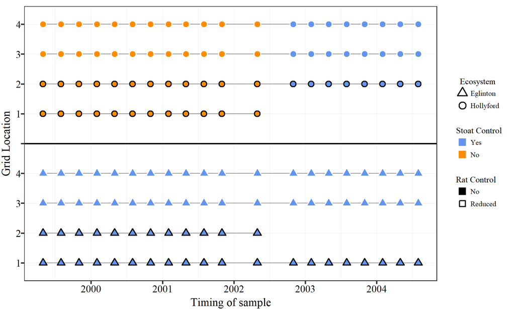

## Seed

### Data

### Plot

```r
# turn seed.paper.2 into plot
# for publication
# May2019

names(abund.dat5)
```

```
 [1] "N"              "se.N"           "lcl.N"          "ucl.N"
 [5] "var"            "grid"           "trip"           "grid.n"
 [9] "trip.no"        "valley"         "control"        "Valley"
[13] "year"           "month"          "cum.seed"       "seed.account.N"
[17] "log.seed"       "valley.rep"     "grid.rats"      "Conditions"
[21] "grouping.1"     "grouping.2"     "grouping.3"     "grouping.4"
[25] "true.date"      "treat.six"
```

```
N

se.N

lcl.N

ucl.N

var

grid

trip

grid.n

trip.no

valley

control

Valley

year

month

cum.seed

seed.account.N

log.seed

valley.rep

grid.rats

Conditions

grouping.1

grouping.2

grouping.3

grouping.4

true.date

treat.six
```

```r
# Valley and Control summaries
seed.2mean <- plot.dat.all1 %>%
  group_by(Control, Valley, Date) %>%
  summarise(
    mean.s = mean(cum.seed),
    sd.s = sd(cum.seed),
    se.s = sd(cum.seed) / sqrt(length(cum.seed)) * 1.96,
    lcl.s = mean(cum.seed) - (sd(cum.seed) / sqrt(length(cum.seed)) *
                                1.96),
    ucl.s = mean(cum.seed) + (sd(cum.seed) / sqrt(length(cum.seed)) *
                                1.96)
  ) %>%
  ungroup()

# Valley, control and Conditions summaries
seed.2mean <- plot.dat.all1 %>%
  group_by(Control, Valley, Date) %>%
  summarise(
    mean.s = mean(cum.seed),
    sd.s = sd(cum.seed),
    se.s = sd(cum.seed) / sqrt(length(cum.seed)) * 1.96,
    lcl.s = mean(cum.seed) - (sd(cum.seed) / sqrt(length(cum.seed)) *
                                1.96),
    ucl.s = mean(cum.seed) + (sd(cum.seed) / sqrt(length(cum.seed)) *
                                1.96)
  ) %>%
  ungroup()


# levels(seed.2mean$gp.treat)
# note that plot uses both meanS and meanS.1
# seed.aver.plot <-
base.plot <- ggplot(data = plot.dat.all1,
       aes(y = cum.seed,
         x = Date,
         shape = Valley,
         fill = Control,
         col = Rats)) +

  # extra goodies
  geom_rect(aes(
    xmin = ymd('2000-01-01'),
    xmax = ymd('2000-12-31'),
    ymin = -Inf,
    ymax = Inf
  ),
  colour = "grey90",
  fill = "grey90") +

  geom_rect(aes(
    xmin = ymd('2002-01-01'),
    xmax = ymd('2002-12-31'),
    ymin = -Inf,
    ymax = Inf
  ),
  colour = "grey90",
  fill = "grey90") +

  geom_rect(aes(
    xmin = ymd('2004-01-01'),
    xmax = ymd('2004-12-31'),
    ymin = -Inf,
    ymax = Inf
  ),
  colour = "grey90",
  fill = "grey90") +

  geom_point(aes(fill = Control), stroke = 1.15, size = 3)

# +
   # geom_line(data = seed.2mean, aes(y = mean.s, x = Date), size = 0.9)
#
  # # +
  #   # geom_errorbar(data = meanS.1, mapping = aes(ymin = lcl.s, ymax = ucl.s), width = 0, alpha = 0.5, lwd = 0.75) +
  #
  # geom_line(data = seed.2mean,
  #           aes(y = mean.s,
  #               x = Date),
  #           size = 1,
  #           col = "grey50") +
  #
  # geom_point(data = seed.2mean, aes(y = mean.s,
  #                                  x = Date), size = 5) +
  #
  #
  #
  # scale_color_manual(name = "Stoat Control",
  #                    values = c("white", "black")) +
  #
  # scale_shape_manual(name = "Ecosystem",
  #                    values = c(24, 21)) +
  #
  # # manually define the fill colours
  # #
  # scale_fill_manual(
  #   name = "Stoat Control",
  #   values = c("cornflowerblue", "darkorange", "white", "black")
  # ) +
  #
  # # defining size with 2 marginally different values
  # scale_size_manual(name = "Rat Control", values = c(5, 4)) +
  #
  # # geom_abline(intercept = 5, slope = 0, size = 1) +
  # # theme
  # theme_new() +
  #
  #
  # # labels
  # # scale_y_discrete(labels = c("1","2","3","4"," ","1","2","3","4")) +
  # # scale_x_date() +
  # # defining size with 2 marginally different values
  # # scale_size_manual(name = "Rat Control", values = c(4, 3)) +
  #
  # # Remove fill legend and replace the fill legend using the newly created size
  # guides(
  #   col = "none",
  #   shape = guide_legend(override.aes = list(shape = c(24, 21))),
  #   fill = guide_legend(override.aes = list(col = c(
  #     "cornflowerblue", "darkorange"
  #   )))
  # )



# study design plot
# may 2019
#anthony

source("./rcode/davidson_2019_theme.r")
# source("./rcode/figures/study-design-data.R")

p.design <- plot.dat.all1 %>%
  mutate(grid = as.numeric(factor(grid)))

# glimpse(plot.dat.all1)

# adding NA grid to plot

bd.row <- p.design[1, ]
bd.row$grid <- "blank"
bd.row$grid <- "blank"
bd.row$grid <- "blank"
bd.row$grid <- "blank"
bd.row$Date <- NA

# bind row to plot data
p.design145 <- rbind(p.design, bd.row)
# glimpse(p.design145$grid)

# labels
rat.labs <- c("No", "Reduced")

#re-factoring
p.design1 <- p.design145  %>%
  mutate(grid = factor(grid, levels = c(
    "1", "2", "3", "4", "blank", "5", "6", "7", "8"
  )),
  Rats = factor(Rats, labels = rat.labs))


#checking
# tail(p.design1)
# tail(filter(p.design1, grid == "blank"))
# levels(p.design1$grid)
# labels() <- c("1","2","3","4"," ","5","6","7","8")

# p.design1$grid <- factor(p.design1$grid,  labels = c("1","2","3","4"," ","1","2","3","4"))

#plot raw seed
fig.3.plot.seed <- ggplot(p.design1,
                          aes(
                            y = cum.seed,
                            col = Rats,
                            shape = Valley,
                            fill = Control,
                            x = Date
                          ),
                          size = 4) +
  # geom_line(col = "grey50") +
  geom_point(aes(size = Rats,
                 group = grid), stroke = 1.25) +

  scale_color_manual(name = "Stoat Control",
                     values = c("white", "black")) +

  scale_shape_manual(name = "Ecosystem",
                     values = c(24, 21)) +

  # manually define the fill colours

  scale_fill_manual(name = "Stoat Control",
                    values = c("cornflowerblue", "darkorange")) +
  # geom_abline(intercept = 5, slope = 0, size = 1) +
  # theme
  theme_new() +

  scale_size_manual(name = "Rat Control", values = c(4, 3)) +
  # labels
  # scale_y_discrete(labels = c("1","2","3","4"," ","1","2","3","4")) +
  # scale_x_date() +
  # defining size with 2 marginally different values

  # Remove fill legend and replace the fill legend using the newly created size
  guides(
    col = "none",
    size = guide_legend(override.aes = list(shape = c(16, 1))),
    shape = guide_legend(override.aes = list(
      shape = c(24, 21), size = 4
    )),
    fill = guide_legend(override.aes = list(
      col = c("cornflowerblue", "darkorange"),
      size = 4
    ))
  ) +
  #   col = "none",
  #   # size = guide_legend(override.aes = list(shape = c(16, 1))),
  #   shape = guide_legend(override.aes = list(
  #     shape = c(24, 21), size = 4
  #   ))
  #   # fill = guide_legend(override.aes = list(
  #     # col = c("cornflowerblue", "darkorange"), size = 4
  #   # ))
  # ) +

  #   geom_hline(yintercept = 0,
#              lty = 5,
#              alpha = 0.7)  +
#
xlab(expression(paste("Time", "(", italic(t), ")"))) +

  ylab(expression(paste("Available seed ", "(", italic(Seed[jt]), ")")))

# fig.3.plot.seed


# sorting summary dataset for the last time -------------------------------
#summarising seed
table(is.na(p.design1$grid))
```

```
FALSE
  145
```

```r
#remove NA for making space in last plot
p.design1 <- p.design1[1:144, ]
#no grid na anymore
table(is.na(p.design1$grid))
```

```
FALSE
  144
```

```r
#making datasest
p.design2 <- p.design1 %>%
  group_by(Control, Valley, Date) %>%
  summarise(cum.seed = mean(cum.seed),
            Rats = factor("Full", levels = c("Full", "Reduced"))) %>%
  ungroup() %>%
  mutate(grid = factor(paste(Control, Valley)))

# grouping of grid correct?
levels(p.design2$grid)
```

```
[1] "No Hollyford"  "Yes Eglinton"  "Yes Hollyford"
```

```
No Hollyford

Yes Eglinton

Yes Hollyford
```

```r
p.design2$Rats
```

```
 [1] Full Full Full Full Full Full Full Full Full Full Full Full Full Full
[15] Full Full Full Full Full Full Full Full Full Full Full Full Full Full
[29] Full Full Full Full Full Full Full Full Full Full Full Full
Levels: Full Reduced
```

```r
# glimpse(p.design2)
#plot summary seed

# Add NA so legend works
row.input.leg <- p.design2[1, ]
row.input.leg$Control <- NA
row.input.leg$Valley <- NA
row.input.leg$Date <- NA
row.input.leg$cum.seed <- NA
row.input.leg$Rats <- "Reduced"
row.input.leg$grid <- NA

p.design3 <- rbind(p.design2, row.input.leg)
# glimpse(p.design3)
levels(p.design3$Rats)
```

```
[1] "Full"    "Reduced"
```

```
Full

Reduced
```

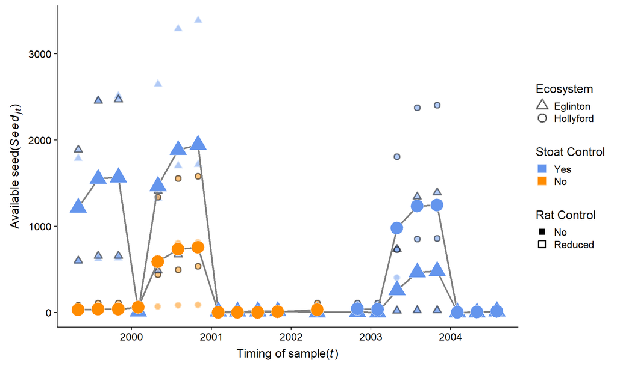

```r
col = c("cornflowerblue", "darkorange")

#plot raw seed
fig.3.plot.seed.sum <- ggplot(p.design2,
                              aes(
                                y = cum.seed,
                                col = Rats,
                                shape = Valley,
                                fill = Control,
                                x = Date
                              ),
                              size = 4) +
  geom_line(col = "grey50") +
  geom_point(aes(size = Rats,
                 group = grid), stroke = 1.25) +

  scale_color_manual(name = "Stoat Control",
                     values = c("white", "black")) +

  scale_shape_manual(name = "Ecosystem",
                     values = c(24, 21)) +

  scale_size_manual(name = "Rat Control", values = c(4, 3)) +
  # manually define the fill colours

  scale_fill_manual(name = "Stoat Control",
                    values = c("cornflowerblue", "darkorange")) +
  # geom_abline(intercept = 5, slope = 0, size = 1) +
  # theme
  theme_new() +


  # labels
  # scale_y_discrete(labels = c("1","2","3","4"," ","1","2","3","4")) +
  # scale_x_date() +
  # defining size with 2 marginally different values

  # Remove fill legend and replace the fill legend using the newly created size
  guides(
    col = "none",
    size = "none",
    shape = guide_legend(override.aes = list(
      shape = c(24, 21), size = 4
    )),
    fill = guide_legend(override.aes = list(
      col = c("cornflowerblue", "darkorange"),shape = c("square"),
      size = 4
    ))
  ) +
  #   col = "none",
  #   # size = guide_legend(override.aes = list(shape = c(16, 1))),
  #   shape = guide_legend(override.aes = list(
  #     shape = c(24, 21), size = 4
  #   ))
  #   # fill = guide_legend(override.aes = list(
  #     # col = c("cornflowerblue", "darkorange"), size = 4
  #   # ))
  # ) +

  #   geom_hline(yintercept = 0,
#              lty = 5,
#              alpha = 0.7)  +
#
xlab(expression(paste("Time", "(", italic(t), ")"))) +

  ylab(expression(paste("Available seed ", "(", italic(Seed[jt]), ")")))

# fig.3.plot.seed.sum



# Combine them ------------------------------------------------------------

#plot raw seed
fig.3.seed <- ggplot(p.design1,
                     aes(
                       y = cum.seed,
                       col = Rats,
                       shape = Valley,
                       fill = Control,
                       x = Date
                     )) +
  # geom_line(col = "grey50") +
  geom_point(aes(size = Rats,
                 group = grid),
             stroke = 1.25,
             alpha = 0.5) +

  scale_color_manual(name = "Stoat Control",
                     values = c("white", "black", "white")) +

  scale_shape_manual(name = "Ecosystem",
                     values = c(24, 21)) +

  scale_size_manual(name = "Rat Control", values = c(2.5, 3, 2.5)) +
  # manually define the fill colours

  scale_fill_manual(
    name = "Stoat Control",
    values = c("cornflowerblue", "darkorange", "cornflowerblue")
  ) +


  geom_line(
    data = p.design2,
    aes(y = cum.seed,
        x = Date),
    size = 0.95,
    col = "grey50"
  ) +

  geom_point(
    data = p.design2,
    aes(
      y = cum.seed,
      col = Rats,
      shape = Valley,
      fill = Control,
      x = Date
    ),
    size = 7
  ) +

  # Remove fill legend and replace the fill legend using the newly created size
  guides(
    col = "none",
    size = guide_legend(override.aes = list(
  shape = c(15,0),alpha = 1
    )),
    shape = guide_legend(override.aes = list(
      shape = c(24, 21), size = 4
    )),
    fill = guide_legend(override.aes = list(
      col = c("cornflowerblue", "darkorange"),shape = c("square"),
      size = 4
    ))
  ) +

  xlab(expression(paste("Timing of sample", "(", italic(t), ")"))) +

  ylab(expression(paste("Available seed ", "(", italic(Seed[jt]), ")")))

fig.3.seed
```

```r
# export plot for example vignette
# jpeg("./figs/fig-3.1-study.jpeg")
# fig.3.seed
# dev.off()
```

## Mice

## Data

### Plot

| N | se.N | lcl.N | ucl.N | var | grid | trip | grid.n | trip.no | valley | control | Valley | year | month | cum.seed | seed.account.N | log.seed | valley.rep | grid.rats | Conditions | grouping.1 | grouping.2 | grouping.3 | grouping.4 | true.date | treat.six | Rats | Control | Date | Treatments | … |
| --- | --- | --- | --- | --- | --- | --- | --- | --- | --- | --- | --- | --- | --- | --- | --- | --- | --- | --- | --- | --- | --- | --- | --- | --- | --- | --- | --- | --- | --- | --- |
| 85.1859200 | 17.2583357 | 53 | 114 | N[1,1] | egl M1 | 1 | 1 | 1 | egl | control | Eglinton | 1999 | May | 590.781767 | 6.9352044 | 2.7714271 | egl | M1 | rats.removed | treat.highN | treat.highN | treat.highN | treat.highN | 1999-05-01 | egl control rats.removed | Reduced | Yes | 1999-05-01 | egl control rats.removed | … |
| 141.3464533 | 24.8136961 | 103 | 200 | N[2,1] | egl M1 | 2 | 1 | 2 | egl | control | Eglinton | 1999 | Aug | 621.339445 | 4.3958616 | 2.7933289 | egl | M1 | rats.removed | treat.highN | treat.highN | treat.highN | treat.highN | 1999-08-01 | egl control rats.removed | Reduced | Yes | 1999-08-01 | egl control rats.removed | … |
| 125.5429067 | 15.7174287 | 100 | 162 | N[3,1] | egl M1 | 3 | 1 | 3 | egl | control | Eglinton | 1999 | Nov | 631.525337 | 5.0303546 | 2.8003908 | egl | M1 | rats.removed | treat.highN | treat.highN | treat.highN | treat.highN | 1999-11-01 | egl control rats.removed | Reduced | Yes | 1999-11-01 | egl control rats.removed | … |
| 23.7692733 | 1.6613580 | 22 | 28 | N[4,1] | egl M1 | 4 | 1 | 4 | egl | control | Eglinton | 2000 | Feb | 20.371785 | 0.8570639 | 1.3090291 | egl | M1 | rats.removed | treat.lowN | treat.highN | treat.highN | treat.highN | 2000-02-01 | egl control rats.removed | Reduced | Yes | 2000-02-01 | egl control rats.removed | … |
| 89.5302533 | 18.5405013 | 57 | 125 | N[5,1] | egl M1 | 5 | 1 | 5 | egl | control | Eglinton | 2000 | May | 1324.166030 | 14.7901517 | 3.1219424 | egl | M1 | rats.removed | treat.highN | treat.highN | treat.highN | treat.highN | 2000-05-01 | egl control rats.removed | Reduced | Yes | 2000-05-01 | egl control rats.removed | … |
| 132.5741133 | 24.5620601 | 88 | 179 | N[6,1] | egl M1 | 6 | 1 | 6 | egl | control | Eglinton | 2000 | Aug | 1701.044054 | 12.8308914 | 3.2307156 | egl | M1 | rats.removed | treat.highN | treat.highN | treat.highN | treat.highN | 2000-08-01 | egl control rats.removed | Reduced | Yes | 2000-08-01 | egl control rats.removed | … |
| 122.0759400 | 18.1190611 | 93 | 164 | N[7,1] | egl M1 | 7 | 1 | 7 | egl | control | Eglinton | 2000 | Nov | 1716.322893 | 14.0594690 | 3.2345990 | egl | M1 | rats.removed | treat.highN | treat.highN | treat.highN | treat.highN | 2000-11-01 | egl control rats.removed | Reduced | Yes | 2000-11-01 | egl control rats.removed | … |
| 31.7279867 | 4.5500564 | 25 | 43 | N[8,1] | egl M1 | 8 | 1 | 8 | egl | control | Eglinton | 2001 | Feb | 0.000000 | 0.0000000 | 0.0000000 | egl | M1 | rats.removed | treat.lowN | treat.highN | treat.lowN | treat.lowN | 2001-02-01 | egl control rats.removed | Reduced | Yes | 2001-02-01 | egl control rats.removed | … |
| 17.7766000 | 3.4972180 | 13 | 26 | N[9,1] | egl M1 | 9 | 1 | 9 | egl | control | Eglinton | 2001 | May | 0.000000 | 0.0000000 | 0.0000000 | egl | M1 | rats.removed | treat.lowN | treat.highN | treat.lowN | treat.lowN | 2001-05-01 | egl control rats.removed | Reduced | Yes | 2001-05-01 | egl control rats.removed | … |
| 1.7254933 | 1.4848549 | 0 | 5 | N[10,1] | egl M1 | 10 | 1 | 10 | egl | control | Eglinton | 2001 | Aug | 0.000000 | 0.0000000 | 0.0000000 | egl | M1 | rats.removed | treat.lowN | treat.lowN | treat.lowN | treat.lowN | 2001-08-01 | egl control rats.removed | Reduced | Yes | 2001-08-01 | egl control rats.removed | … |

[output cut: 134 more lines]

```
FALSE
  144
```

```
FALSE
  144
```

```
[1] "No Hollyford"  "Yes Eglinton"  "Yes Hollyford"
```

```
No Hollyford

Yes Eglinton

Yes Hollyford
```

```
 [1] Full Full Full Full Full Full Full Full Full Full Full Full Full Full
[15] Full Full Full Full Full Full Full Full Full Full Full Full Full Full
[29] Full Full Full Full Full Full Full Full Full Full Full Full
Levels: Full Reduced
```

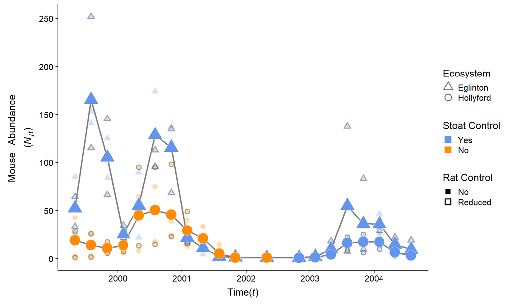

## Rats

### Data

### Plot

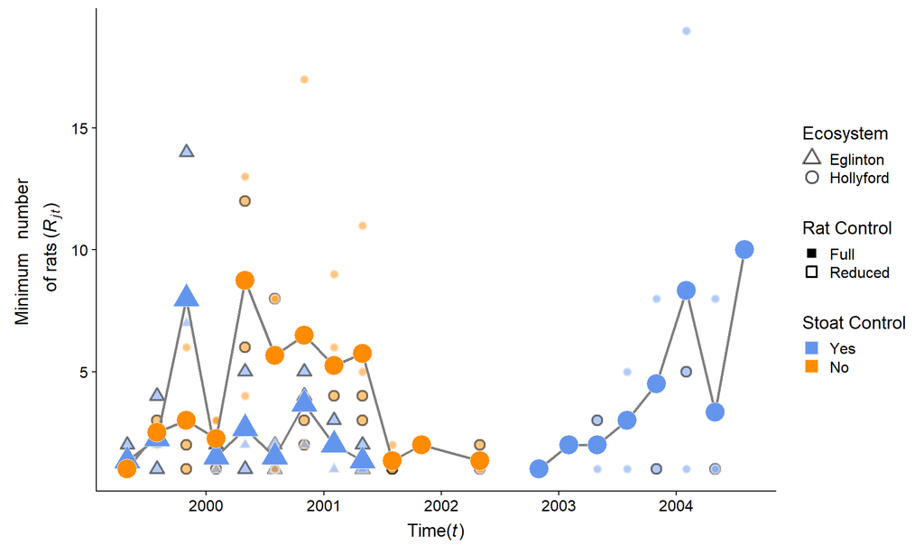

# Bug fixed!!

## Solution!

I have manually fixed the manuscript code here when mering seed and N. **Above no-longer is an issue using the Tidyverse set of tools (Ross, Wickham, and Robinson 2017).**

Kellner, Ken. 2018. *jagsUI: A Wrapper Around ’Rjags’ to Streamline ’JAGS’ Analyses*.

King, Carolyn M. 1983. “The Relationships Between Beech (Nothofagus Sp.) Seedfall and Populations of Mice (Mus Musculus), and the Demographic and Dietary Responses of Stoats (Mustela Erminea), in Three New Zealand Forests.” *Journal of Animal Ecology* 52 (1): 141–66.

Ross, Zev, Hadley Wickham, and David Robinson. 2017. “Declutter Your R Workflow with Tidy Tools.” Preprint. PeerJ Preprints. doi:10.7287/peerj.preprints.3180v1.

Ruscoe, Wendy A, Joseph S Elkinton, David Choquenot, and Robert B Allen. 2005. “Predation of Beech Seed by Mice: Effects of Numerical and Functional Responses.” *Journal of Animal Ecology* 74: 1005–19. doi:10.1111/j.1365-2656.2005.00998.x.

Wardle, P. 1991. *Vegetation of New Zealand*. Cambridge University Press.